# DSCI353-353m-453: Class 07b p1Linear & Kernel Support Vector Machine

Profs: R. H. French, L. S. Bruckman, P. Leu, K. Davis, S. Cirlos

TAs: W. Oltjen, K. Hernandez, M. Li, M. Li, D. Colvin

02 March, 2023

#### Class Readings, Assignments, Syllabus Topics

#### Machine Learning and Kernels

- A common application of machine learning (ML)
  - is the learning and classification of a set of raw data features
  - by a ML algorithm or technique.

In this context a ML kernel

- acts to the ML algorithm like sunshades,
  - a telescope or a magnifying glass
- to the observing eye of a student learner.

A good kernel

- filters the raw data
- and presents its features to the machine
- in a way that makes the learning task as simple as possible.

Historically a lot of progress in machine learning

- has been made in the development sophisticated learning algorithms,
- however selecting appropriate kernels
  - remains a largely manual and time consuming task.

This discussion is inspired by a presentation

- by Prof. Mehryar Mohri about [learning kernels](http://www.cs.nyu.edu/~mohri/icml2011-tutorial/).

It reflects on the importance of kernels

- in support vector machines (SVM).

A total of three examples are presented.

- A linear kernel is shown to solve the first example
  - but fails for the second task.
- There a square kernel is successful.
- Then a third example is presented
  - that both linear and square kernels are not sufficient.

A successful kernel can be generated

- out of a mixture of both base kernels.

This illustrates that kernels can be generated out of bases,

- resulting in products that are more powerful
- in solving the task at hand
- than each individual components.

#### Support Vector Machines

- Consider a support vector machine (SVM) for a classification task.

Given a set of

- pairs of feature data-point vectors $x$
  - and classifier labels $y={-1,1}$,
- the task of the SVM algorithm
  - is to learn to group features $x$ by classifier labels $y$.

After training on a known data set

- the SVM machine is intended to correctly predict the class $y$
- of an previously unseen feature vector $x$.

Applications in quantitative finance of support vector machines

- include for example predictive tasks,
- where $x$ consists of features
  - derived from a historical stock indicator time series
- and $y$ is a sell or buy signal.

Another example could be

- that $x$ consist of counts of key-words within a text
  - such as an news announcements
- and $y$ categorizes it again
  - according on its impact to market movements.

Outside of finance a text based SVM

- could be used to filter e-mail to be forwarded
- to either the inbox or the spam folder.

##### Linear Kernel

- As indicated above the SVM works
  - by grouping feature points according to its classifiers.

For illustration in the toy example below

- two dimensional feature vectors $x={x1,x2}$
- are generated in such a way that the class $y=-1$ points (triangles)
- are nicely separated from the class $y=1$ (circles).

The SVM algorithm finds the largest possible linear margin

- that separates these two regions.

The marginal separators

- rest on the outpost points
  - that are right on the front line of their respective regions.
- These points,
  - marked as two bold triangles and one bold circle in the picture below,
- are named the ‘support vectors’
  - as they are supporting the separation boundary lines.

In fact the SVM learning task

- fully consists of determining these support vector points
  - and the margin distance that separates the regions.

After training

- all other non-support points
- are not used for prediction.

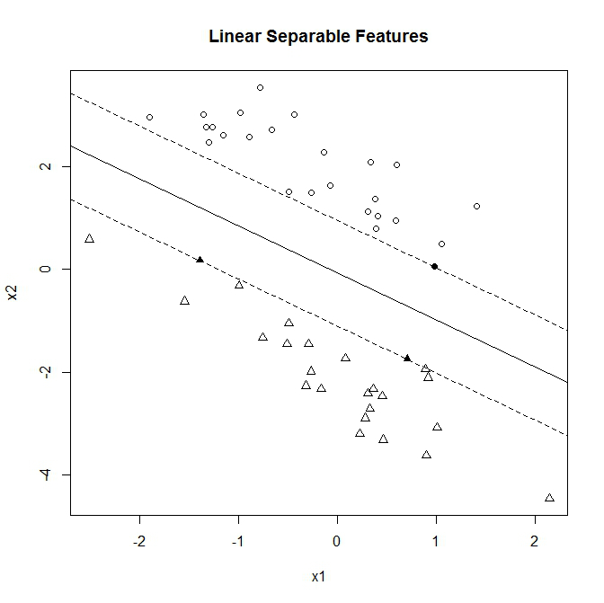

Linear Separable Features

In linear feature space

- the support vectors add to an overall hypothesis vector
  - $h$, $h = \sum c_i x_i$,
- such that the classification frontiers are given by the lines
  - $h x + b = 1$ and $h x + b = -1$ centered around $h x + b = 0$.

The code below utilizes the ksvm implementation

- in the R package ‘kernlab’,
- making use of “[Jean-Philippe Vert’s](http://cbio.ensmp.fr/~jvert/)” tutorials
- for graphing the classification separation lines.

Lets define a function `kfunction`

```r
# require('kernlab')
library(tidyverse)
library(kernlab)

?kernlab::ksvm

kfunction <- function(linear = 0, quadratic = 0) {
  k <- function(x, y)  {
    linear * sum((x) * (y)) + quadratic * sum((x ^ 2) * (y ^ 2))
  }
  class(k) <- "kernel"
  k
}
```

```r
n <- 25
a1 <- rnorm(n)
a2 <- 1 - a1 + 2 * runif(n)
b1 <- rnorm(n)
b2 <- -1 - b1 - 2 * runif(n)
x <- rbind(matrix(cbind(a1, a2), , 2), matrix(cbind(b1, b2), , 2))
y <- matrix(c(rep(1, n), rep(-1, n)))

glimpse(x)
```

```
 num [1:50, 1:2] -1.2196 -0.0795 -1.7498 0.4014 0.934 ...
```

```r
glimpse(y)
```

```
 num [1:50, 1] 1 1 1 1 1 1 1 1 1 1 ...
```

Lets define another function `ksvm`

```r
svp <- ksvm(
  x,
  y,
  type = "C-svc",
  C = 100,
  kernel = kfunction(1, 0),
  scaled = c()
)
```

Now lets look at the results

```r
{
  plot(
    c(min(x[, 1]), max(x[, 1])),
    c(min(x[, 2]), max(x[, 2])),
    type = 'n',
    xlab = 'x1',
    ylab = 'x2'
  )
  title(main = 'Linear Separable Features')
}
ymat <- ymatrix(svp)
points(x[-SVindex(svp), 1], x[-SVindex(svp), 2],
       pch = ifelse(ymat[-SVindex(svp)] < 0, 2, 1))
```

```r
points(x[SVindex(svp), 1], x[SVindex(svp), 2],
       pch = ifelse(ymat[SVindex(svp)] < 0, 17, 16))

# Extract w and b from the model
w <- colSums(coef(svp)[[1]] * x[SVindex(svp),])
b <- b(svp)

# Draw the lines
abline(b / w[2], -w[1] / w[2])
```

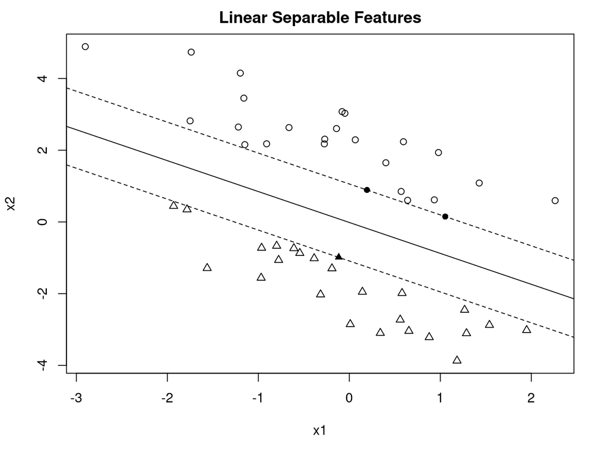

```r
abline((b + 1) / w[2], -w[1] / w[2], lty = 2)
abline((b - 1) / w[2], -w[1] / w[2], lty = 2)
```

##### Quadratic Kernel

- The following example illustrates a case
  - where the feature points are non-linear separated.

Points of the class $y=1$ (circles below)

- are placed in a inner region
  - surrounded from all sides by points of class y = -1,
  - again depicted as triangles.

In this example there is no single straight (linear) line

- that can separate both regions.

However here it is still possible to find such a separator

- by transforming the points $x=\{x_1, x_2\}$ from feature space
- to a quadratic kernel space
  - with points given by the corresponding square coordinates $\{x_1^2, x_2^2\}$.

The technique of transforming from feature space

- into a measure that allows for a linear separation
  - can be formalized in terms of kernels.

Assuming $\Phi()$ is a vector coordinate transformation function.

- For example a squared coordinate space would be
  - $\{ \Phi(x)_1 , \Phi(x)_2 \} = \{ x_1^2 , x_2^2 \}$.
- The SVM separation task is now acting in the transformed space
  - to find the support vectors that generate

$$h \Phi(x) + b = \pm 1$$

for the hypothesis vector $h = \sum c_i \Phi(x_i)$

- given by the sum over support vector points $x_i$.

Putting both expressions together we get

$$\sum c_i K(x_i,x) + b = \pm
1$$

with the scalar kernel function
$$K(x_i,x)
= \Phi(x_i) \Phi(x)$$
.

The kernel is composed out of the scalar product

- between a support vector $x_i$
- and another feature vector point $x$
  - in the transformed space.

In practice the SVM algorithm

- can be fully expressed in terms of kernels
  - without having to actually specify the feature space transformation.

Popular kernels are for example

- higher powers of the linear scalar product (polynomial kernel).
- Another example is
  - a probability weighed distance between two points (Gaussian kernel).

Implementing a two dimensional quadratic kernel function

- allows the SVM algorithm to find support vectors
  - and correctly separate the regions.

The graph below illustrates that

- the non-linear regions are linearly separated
- after transforming to the squared kernel space.

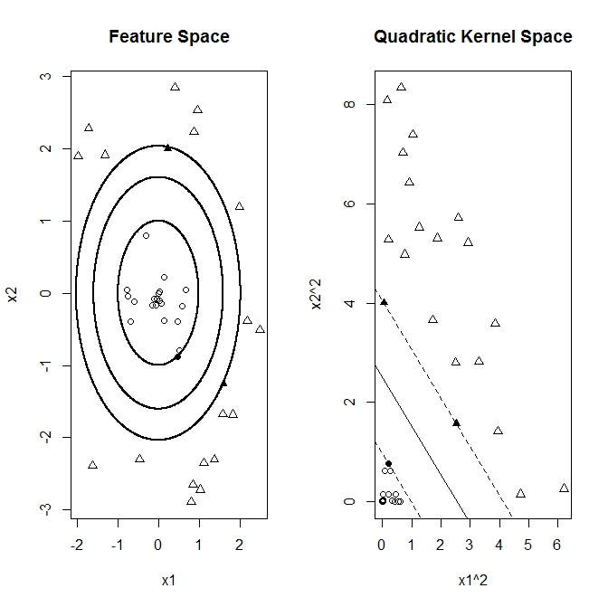

Quadratic Kernel

The “R” implementation makes use of ksvm’s flexibility

- to allow for custom kernel functions.
- The function `kfunction`’
  - returns a linear scalar product kernel for parameters (1,0)
  - and a quadratic kernel function for parameters (0,1).

```r
library('kernlab')
kfunction <- function(linear = 0, quadratic = 0)
{
  k <- function(x, y)
  {
    linear * sum((x) * (y)) + quadratic * sum((x ^ 2) * (y ^ 2))
  }
  class(k) <- "kernel"
  k
}

n = 20
r = runif(n)
a = 2 * pi * runif(n)
a1 = r * sin(a)
a2 = r * cos(a)
r = 2 + runif(n)
a = 2 * pi * runif(n)
b1 = r * sin(a)
b2 = r * cos(a)
x = rbind(matrix(cbind(a1, a2), , 2), matrix(cbind(b1, b2), , 2))
y <- matrix(c(rep(1, n), rep(-1, n)))

glimpse(x)
```

```
 num [1:40, 1:2] 0.2211 -0.2727 -0.0601 -0.7256 0.375 ...
```

```r
glimpse(r)
```

```
 num [1:20] 2.49 2.49 2.78 2.41 2.03 ...
```

```r
svp <-
  ksvm(
    x,
    y,
    type = "C-svc",
    C = 100,
    kernel = kfunction(0, 1),
    scaled = c()
  )
par(mfrow = c(1, 2))
plot(
  c(min(x[, 1]), max(x[, 1])),
  c(min(x[, 2]), max(x[, 2])),
  type = 'n',
  xlab = 'x1',
  ylab = 'x2'
)
title(main = 'Feature Space')
```

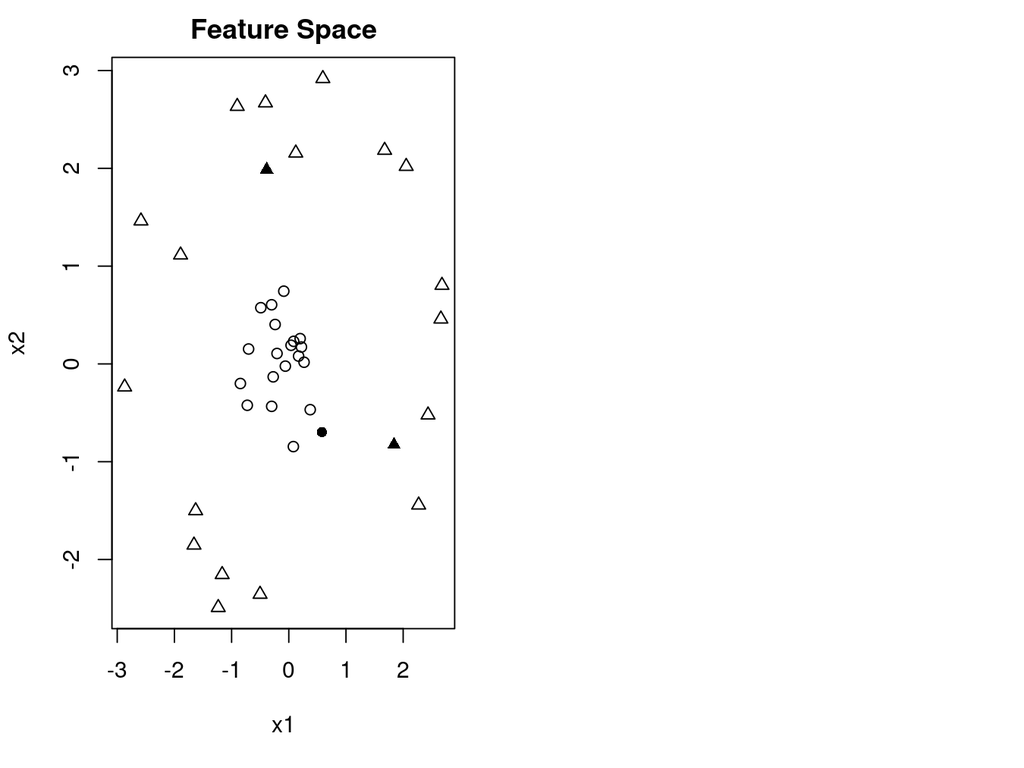

```r
ymat <- ymatrix(svp)
points(x[-SVindex(svp), 1], x[-SVindex(svp), 2],
       pch = ifelse(ymat[-SVindex(svp)] < 0, 2, 1))
points(x[SVindex(svp), 1], x[SVindex(svp), 2],
       pch = ifelse(ymat[SVindex(svp)] < 0, 17, 16))
```

```r
# Extract w and b from the model
w2 <- colSums(coef(svp)[[1]] * x[SVindex(svp), ] ^ 2)
b <- b(svp)

x1 = seq(min(x[, 1]), max(x[, 1]), 0.01)
x2 = seq(min(x[, 2]), max(x[, 2]), 0.01)

plot.new()

points(-sqrt((b - w2[1] * x2 ^ 2) / w2[2]), x2, pch = 16 , cex = .1)
```

```r
points(sqrt((b - w2[1] * x2 ^ 2) / w2[2]), x2, pch = 16 , cex = .1)
points(x1, sqrt((b - w2[2] * x1 ^ 2) / w2[1]), pch = 16 , cex = .1)
```

```r
points(x1,  -sqrt((b - w2[2] * x1 ^ 2) / w2[1]), pch = 16, cex = .1)

points(-sqrt((1 + b - w2[1] * x2 ^ 2) / w2[2]) , x2, pch = 16 , cex = .1)
```

```r
points(sqrt((1 + b - w2[1] * x2 ^ 2) / w2[2]) , x2,  pch = 16 , cex = .1)
points(x1 , sqrt((1 + b - w2[2] * x1 ^ 2) / w2[1]), pch = 16 , cex = .1)
```

```r
points(x1 , -sqrt((1 + b - w2[2] * x1 ^ 2) / w2[1]), pch = 16, cex = .1)

points(-sqrt((-1 + b - w2[1] * x2 ^ 2) / w2[2]) , x2, pch = 16 , cex = .1)
```

```r
points(sqrt((-1 + b - w2[1] * x2 ^ 2) / w2[2]) , x2,  pch = 16 , cex = .1)
points(x1 , sqrt((-1 + b - w2[2] * x1 ^ 2) / w2[1]), pch = 16 , cex = .1)
```

[figure not shown]

```r
points(x1 , -sqrt((-1 + b - w2[2] * x1 ^ 2) / w2[1]), pch = 16, cex = .1)
```

```r
xsq <- x ^ 2
svp <-
  ksvm(
    xsq,
    y,
    type = "C-svc",
    C = 100,
    kernel = kfunction(1, 0),
    scaled = c()
  )

plot(
  c(min(xsq[, 1]), max(xsq[, 1])),
  c(min(xsq[, 2]), max(xsq[, 2])),
  type = 'n',
  xlab = 'x1^2',
  ylab = 'x2^2'
)
title(main = 'Quadratic Kernel Space')
```

```r
ymat <- ymatrix(svp)
points(xsq[-SVindex(svp), 1], xsq[-SVindex(svp), 2],
       pch = ifelse(ymat[-SVindex(svp)] < 0, 2, 1))
points(xsq[SVindex(svp), 1], xsq[SVindex(svp), 2],
       pch = ifelse(ymat[SVindex(svp)] < 0, 17, 16))
```

```r
# Extract w and b from the model
w <- colSums(coef(svp)[[1]] * xsq[SVindex(svp), ])
b <- b(svp)

# Draw the lines
abline(b / w[2], -w[1] / w[2])
abline((b + 1) / w[2], -w[1] / w[2], lty = 2)
```

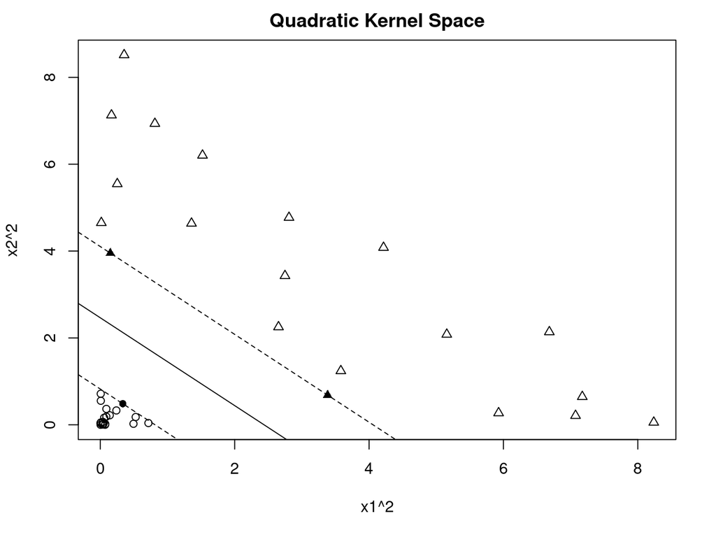

```r
abline((b - 1) / w[2], -w[1] / w[2], lty = 2)
```

##### Alignment and Kernel Mixture

- The final exploratory feature data set
  - consists again of two classes of points
  - within two dimensional space.

This time two distinct regions of points

- are separated by a parabolic boundary,
- where vector points of class $y=1$ (circles) are below
- and $y=-1$ (triangles) are above the separating curve.

The example is selected for its property

- that neither the linear nor the quadratic kernels alone
- are able to resolve the SVM classification problem.

The second graph below illustrates that feature points of both classes

- are scattered onto overlapping regions in the quadratic kernel space.

It indicates that for this case

- the sole utilization of the quadratic kernel
- is not enough to resolve the classification problem.

In [“Algorithms for Learning Kernels Based on Centered Alignment”](http://http//www.cs.nyu.edu/~mohri/pub/alignj.pdf)

- Corinna Cortes, Mehryar Mohri and Afshin Rostamizadeh
- compose mixed kernels out of base kernel functions.

This is perhaps similar to how a vector

- can be composed out of its coordinate base vectors
- or a function can be assembled in functional Hilbert space.

In our example

- we form a new mixed kernel
  - out of the linear and the quadratic kernels $K_1$ and $K_2$

$$K_M(x,z) = \rho_1 K_1(x,z) + \rho_2
K_2(x,z)$$

The graph below demonstrate

- that the mixed kernel successfully solves the classification problem
- even thought each individual base kernels are insufficient on its own.

In experimentation

- the actual values of the mixture weights $\rho_1$, $\rho_2$ are not critical.

Following the study above we choose the weights

- according to how much each individual base kernel
  - on its individual aligned with the raw classification matrix
- $Y = y^T y$ composed out of the classifier vector $y$.

Alignment is based on the observation that

- a perfectly selected kernel matrix $K_{i,j} = K(x_i,x_j)$
- would trivially solve the classification problem
  - if its elements are equal to the $Y$ matrix.
- In that case choosing an arbitrary vector $x_1$ as support
- the the kernel $K(x_1, x_i)$ would give 1
  - if $x_1$ and $x_i$ are in the same category and -1 otherwise.

Similar to the concept of correlation,

- kernel alignment between two kernels
  - is defined by the expectation over the feature space,
  - resulting in matrix products

$$\rho ( K^c_1 , K^c_2 ) = \frac{ <
K^c_1 , K^c_2 > }{ \sqrt{ < K^c_1 , K^c_1 > < K^c_2 ,
K^c_2 > } }$$

The expectation is take

- assuming centered $n \times n$ kernel matrices
  - according to $K^c = (I-(11^T)/n)K(I-(11^T)/n).$
- (For details see [reference](http://http//www.cs.nyu.edu/~mohri/pub/alignj.pdf) above.)

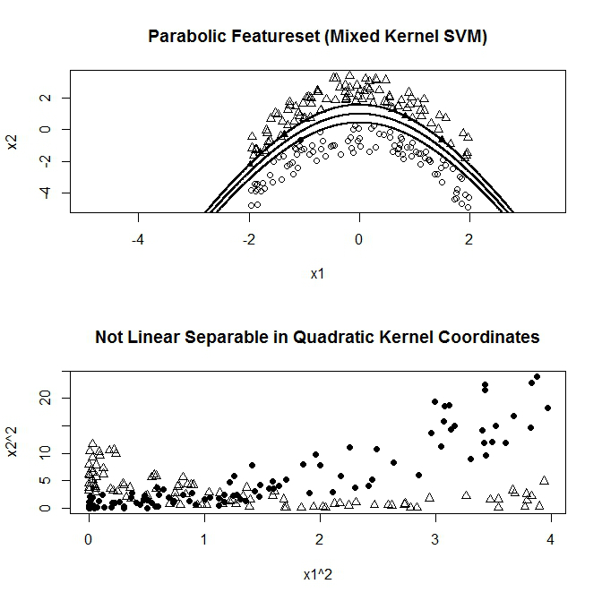

Mixed Kernel

Kernel matrix centering and alignment functions

- are implemented in the ‘R’ as following

Setup

```r
library('kernlab')

kfunction <- function(linear, quadratic) {
  k <- function(x, y) {
    linear * sum((x) * (y)) + quadratic * sum((x ^ 2) * (y ^ 2))
  }
  class(k) <- "kernel"
  k
}

n <- 100
a1 <- 4 * runif(n) - 2
a2 <- 1 - a1 ^ 2 - 0.5 - 2 * runif(n)
b1 <- 4 * runif(n) - 2
b2 <- 1 - b1 ^ 2 + 0.5 + 2 * runif(n)

x <- rbind(matrix(cbind(a1, a2), , 2), matrix(cbind(b1, b2), , 2))
y <- matrix(c(rep(1, n), rep(-1, n)))

glimpse(x)
```

```
 num [1:200, 1:2] 1.717 0.916 1.077 -1.516 -0.975 ...
```

```r
glimpse(y)
```

```
 num [1:200, 1] 1 1 1 1 1 1 1 1 1 1 ...
```

Prep our desired kernel

```r
center_kernel <- function(kernel) {
  m <- length(kernel[, 1])
  ones <- matrix(rep(1, m), m)
  (diag(m) - ones %*% t(ones) / m) * kernel * (diag(m) - ones %*% t(ones) / m)
}
f_product <- function(x, y) {
  sum(diag(crossprod(t(x), y)))
}
f_norm <- function(x) {
  sqrt(f_product(x, x))
}
kernel_alignment <- function(x, y) {
  f_product(x, y) / (f_norm(x) * f_norm(y))
}

x_kernel1 <- kernelMatrix(kfunction(1, 0), x)
y_kernel  <- y %*% t(y)
x_kernel2 <- kernelMatrix(kfunction(0, 1), x)

x_kernel1_c <- center_kernel(x_kernel1)
x_kernel2_c <- center_kernel(x_kernel2)

y_kernel_c <- center_kernel(y_kernel)

alignment1 <- kernel_alignment(x_kernel1_c, y_kernel_c)
alignment2 <- kernel_alignment(x_kernel2_c, y_kernel_c)

x_kernel3 <- kernelMatrix(kfunction(alignment1, alignment2), x)
x_kernel3_c <- center_kernel(x_kernel3)
alignment3 <- kernel_alignment(x_kernel3_c, y_kernel_c)
```

Now lets see the kernel SVM results

```r
svp <- ksvm(
  x,
  y,
  type = "C-svc",
  C = 100,
  kernel = kfunction(alignment1, alignment2),
  scaled = c()
)
par(mfrow = c(2, 1))
plot(
  c(min(x[]), max(x[])),
  c(min(x[]), max(x[])),
  type = 'n',
  xlab = 'x1',
  ylab = 'x2'
)
title(main = 'Parabolic Featureset (Mixed Kernel SVM)')
```

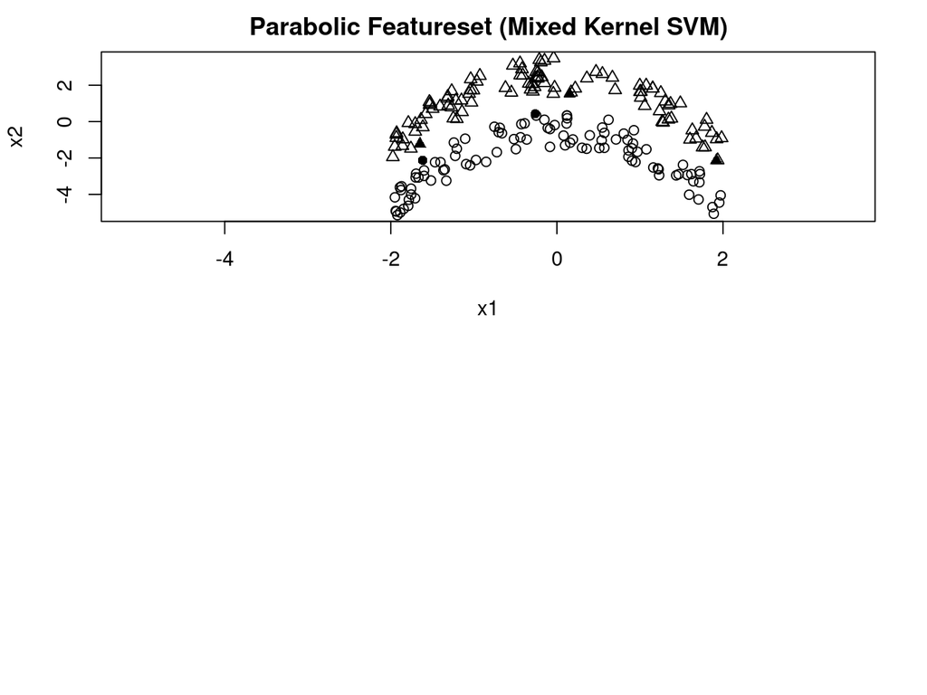

```r
ymat <- ymatrix(svp)
points(x[-SVindex(svp), 1], x[-SVindex(svp), 2],
       pch = ifelse(ymat[-SVindex(svp)] < 0, 2, 1))
points(x[SVindex(svp), 1], x[SVindex(svp), 2],
       pch = ifelse(ymat[SVindex(svp)] < 0, 17, 16))
```

```r
plot.new()

# Extract w and b from the model
w <- colSums(coef(svp)[[1]] * (alignment1 * x[SVindex(svp),]))
v <- colSums(coef(svp)[[1]] * (alignment2 * x[SVindex(svp),] ^ 2))
b <- b(svp)

x1 = seq(min(x[]), max(x[]), 0.01)
x2 = seq(min(x[]), max(x[]), 0.01)

points(sqrt((b - w[2] * x2 - v[2] * x2 ^ 2) / v[1] +
              (w[1] / (2 * v[1])) ^2) - w[1] / (2 * v[1]),
       x2, pch = 16, cex = .1)
```

```r
points(-sqrt((b - w[2] * x2 - v[2] * x2 ^ 2) / v[1] +
               (w[1] / (2 * v[1])) ^2) - w[1] / (2 * v[1]),
       x2, pch = 16, cex = .1)
points(x1, sqrt((b - w[1] * x1 - v[1] * x1 ^ 2) / v[2] +
                  (w[2] / (2 * v[2])) ^2) - w[2] / (2 * v[2]),
       pch = 16, cex = .1)
```

```r
points(x1, -sqrt((b - w[1] * x1 - v[1] * x1 ^ 2) / v[2] +
                   (w[2] / (2 * v[2])) ^2) - w[2] / (2 * v[2]),
       pch = 16, cex = .1)

points(sqrt((1 + b - w[2] * x2 - v[2] * x2 ^ 2) / v[1] +
              (w[1] / (2 * v[1])) ^2) - w[1] / (2 * v[1]), x2, pch = 16, cex = .1)
```

```r
points(-sqrt((1 + b - w[2] * x2 - v[2] * x2 ^ 2) / v[1] +
               (w[1] / (2 * v[1])) ^2) - w[1] / (2 * v[1]), x2, pch = 16, cex = .1)
points(x1, sqrt((1 + b - w[1] * x1 - v[1] * x1 ^ 2) / v[2] +
                  (w[2] / (2 * v[2])) ^ 2) - w[2] / (2 * v[2]), pch = 16, cex = .1)
```

```r
points(x1, -sqrt((1 + b - w[1] * x1 - v[1] * x1 ^ 2) / v[2] +
                   (w[2] / (2 *v[2])) ^ 2) - w[2] / (2 * v[2]), pch = 16, cex = .1)

points(sqrt((-1 + b - w[2] * x2 - v[2] * x2 ^ 2) / v[1] +
              (w[1] / (2 * v[1])) ^2) - w[1] / (2 * v[1]), x2, pch = 16, cex = .1)
```

```r
points(-sqrt((-1 + b - w[2] * x2 - v[2] * x2 ^ 2) / v[1] +
               (w[1] / (2 *v[1])) ^ 2) - w[1] / (2 * v[1]), x2, pch = 16, cex = .1)
points(x1, sqrt((-1 + b - w[1] * x1 - v[1] * x1 ^ 2) / v[2] +
                  (w[2] / (2 * v[2])) ^ 2) - w[2] / (2 * v[2]), pch = 16, cex = .1)
```

[figure not shown]

```r
points(x1, -sqrt((-1 + b - w[1] * x1 - v[1] * x1 ^ 2) / v[2] +
                   (w[2] / (2 * v[2])) ^ 2) - w[2] / (2 * v[2]), pch = 16, cex = .1)
```

```r
plot(x[] ^ 2,
     type = 'n',
     xlab = 'x1^2',
     ylab = 'x2^2')
title(main = 'Not Lin. Sep. in Quad. Kernel Coords.')
points(x[1:100,] ^ 2, pch = 16)
points(x[101:200,] ^ 2, pch = 2)
```

[output not shown]

#### Conclusion

- In conclusion we illuminate
  - the important role of kernel selection
    - in machine learning
  - and demonstrates the use of kernel mixture techniques.

Kernel weights were chosen somewhat ad-hoc

- by alignments to the target classifiers,
- thus preceding the actual SVM learning phase.

More sophisticated algorithms and techniques

- that automate and combine these steps
- are a topic of current ongoing research.

#### Cites

[Machine Learning and Kernels](https://quantsignals.wordpress.com/2012/09/25/kernel-learning-svm/)